# BDA_report

## **广义线性模型扩展：泊松回归**

- 当通过一系列连续型和/或类别型预测变量来预测计数型因变量时，泊松回归是常用的工具,我们的变量中存在大量的类别型变量，故采用泊松回归建立模型。

```r
#根据前面探索性分析的结果，我们选取宗教、婚姻、健康、年龄、收入、社会认知6个自变量进行回归
glm_data <- data[c("happiness","religion","marital","health","age","income","equity","inc_ability")]

#为进行回归分析，需将因子型变量值为-8的行删去
glm_data <- glm_data%>%filter(religion != -8,marital != -8,health != -8,age != -8,income != -8,equity != -8,inc_ability != -8)

#为接下来图标更加值观，将因子型变量的类别编号改为其实际含义
glm_data$religion <- as.character(glm_data$religion)
glm_data$marital <- as.character(glm_data$marital)
glm_data$health <- as.character(glm_data$health)
glm_data$equity <- as.character(glm_data$equity)
glm_data$inc_ability <- as.character(glm_data$inc_ability)
glm_data$religion[as.numeric(glm_data$religion)==0] <- "0 无宗教"
glm_data$religion[as.numeric(glm_data$religion)==1] <- "1 有宗教"
glm_data$marital[as.numeric(glm_data$marital)==1] <- "1 未婚"
glm_data$marital[as.numeric(glm_data$marital)==2] <- "2 同居"
glm_data$marital[as.numeric(glm_data$marital)==3] <- "3 初婚有配偶"
glm_data$marital[as.numeric(glm_data$marital)==4] <- "4 再婚有配偶"
glm_data$marital[as.numeric(glm_data$marital)==5] <- "5 分居未离婚"
glm_data$marital[as.numeric(glm_data$marital)==6] <- "6 离婚"
glm_data$marital[as.numeric(glm_data$marital)==7] <- "7 丧偶"
glm_data$health[as.numeric(glm_data$health)==1] <- "1 很不健康"
glm_data$health[as.numeric(glm_data$health)==2] <- "2 比较不健康"
glm_data$health[as.numeric(glm_data$health)==3] <- "3 一般"
glm_data$health[as.numeric(glm_data$health)==4] <- "4 比较健康"
glm_data$health[as.numeric(glm_data$health)==5] <- "5 很健康"
glm_data$equity[as.numeric(glm_data$equity)==1] <- "1 完全不公平"
glm_data$equity[as.numeric(glm_data$equity)==2] <- "2 比较不公平"
glm_data$equity[as.numeric(glm_data$equity)==3] <- "3 说不上公平不公平"
glm_data$equity[as.numeric(glm_data$equity)==4] <- "4 比较公平"
glm_data$equity[as.numeric(glm_data$equity)==5] <- "5 完全公平"
glm_data$inc_ability[as.numeric(glm_data$inc_ability)==1] <- "1 非常合理"
glm_data$inc_ability[as.numeric(glm_data$inc_ability)==2] <- "2 合理"
glm_data$inc_ability[as.numeric(glm_data$inc_ability)==3] <- "3 非常合理"
glm_data$inc_ability[as.numeric(glm_data$inc_ability)==4] <- "4 非常不合理"
glm_data$religion <- factor(glm_data$religion)
glm_data$marital <- factor(glm_data$marital)
glm_data$health <- factor(glm_data$health)
glm_data$equity <- factor(glm_data$equity)
glm_data$inc_ability <- factor(glm_data$inc_ability)

#为方便实用该模型，将幸福感变为数值型，将收入取对数
glm_data$income <- log(glm_data$income+1)
glm_data$happiness <- as.numeric(as.character(glm_data$happiness))

#加载需要的包
library(stargazer)
library(sjPlot)
library(ggeffects)

#查看整理好用于泊松回归的数据集
glm_data
```

| happiness | religion | marital | health | age | income | equity | inc_ability |
| --- | --- | --- | --- | --- | --- | --- | --- |
| 4 | 1 有宗教 | 3 初婚有配偶 | 3 一般 | 56 | 9.903538 | 3 说不上公平不公平 | 3 非常合理 |
| 4 | 1 有宗教 | 1 未婚 | 5 很健康 | 23 | 9.903538 | 3 说不上公平不公平 | 2 合理 |
| 4 | 0 无宗教 | 3 初婚有配偶 | 4 比较健康 | 48 | 7.601402 | 4 比较公平 | 2 合理 |
| 5 | 1 有宗教 | 7 丧偶 | 4 比较健康 | 72 | 8.767329 | 4 比较公平 | 2 合理 |
| 5 | 1 有宗教 | 3 初婚有配偶 | 5 很健康 | 69 | 8.517393 | 4 比较公平 | 3 非常合理 |
| 4 | 1 有宗教 | 1 未婚 | 2 比较不健康 | 63 | 7.378384 | 4 比较公平 | 3 非常合理 |
| 4 | 1 有宗教 | 3 初婚有配偶 | 4 比较健康 | 30 | 11.002117 | 4 比较公平 | 2 合理 |
| 4 | 1 有宗教 | 3 初婚有配偶 | 4 比较健康 | 27 | 10.085851 | 4 比较公平 | 2 合理 |
| 4 | 0 无宗教 | 3 初婚有配偶 | 4 比较健康 | 47 | 8.987322 | 2 比较不公平 | 2 合理 |
| 4 | 1 有宗教 | 3 初婚有配偶 | 4 比较健康 | 51 | 10.491302 | 3 说不上公平不公平 | 2 合理 |

[output cut: 6613 more lines]

**不考虑变量间交互影响，生成模型**

```r
#不考虑变量间交互影响，生成模型1
model1 <- glm(happiness~religion+marital+health+age+income+equity+inc_ability,data=glm_data,family = poisson())
summary(model1)
```

```
##
## Call:
## glm(formula = happiness ~ religion + marital + health + age +
##     income + equity + inc_ability, family = poisson(), data = glm_data)
##
## Deviance Residuals:
##     Min       1Q   Median       3Q      Max
## -1.9408  -0.1583   0.0255   0.2080   1.2797
##
## Coefficients:
##                            Estimate Std. Error z value Pr(>|z|)
## (Intercept)               1.1110916  0.0756007  14.697  < 2e-16 ***
## religion1 有宗教         -0.0333155  0.0204384  -1.630 0.103092
## marital2 同居             0.0472861  0.0782171   0.605 0.545479
## marital3 初婚有配偶       0.0381279  0.0245236   1.555 0.120007
## marital4 再婚有配偶       0.0039548  0.0527604   0.075 0.940248
## marital5 分居未离婚      -0.0351489  0.1128279  -0.312 0.755400
## marital6 离婚            -0.0746007  0.0502212  -1.485 0.137427
## marital7 丧偶             0.0094267  0.0354494   0.266 0.790300
## health2 比较不健康        0.1107574  0.0440042   2.517 0.011837 *
## health3 一般              0.1650093  0.0429681   3.840 0.000123 ***
## health4 比较健康          0.2013144  0.0423089   4.758 1.95e-06 ***
## health5 很健康            0.2581476  0.0435256   5.931 3.01e-09 ***
## age                       0.0007964  0.0004832   1.648 0.099310 .
## income                    0.0019013  0.0019025   0.999 0.317609
## equity2 比较不公平        0.0169059  0.0317453   0.533 0.594347
## equity3 说不上公平不公平  0.0627565  0.0317149   1.979 0.047841 *
## equity4 比较公平          0.1199293  0.0303689   3.949 7.84e-05 ***
## equity5 完全公平          0.2084281  0.0434633   4.795 1.62e-06 ***
## inc_ability2 合理        -0.0689634  0.0462355  -1.492 0.135813
## inc_ability3 非常合理    -0.1131658  0.0473509  -2.390 0.016851 *
## inc_ability4 非常不合理  -0.1851087  0.0602927  -3.070 0.002139 **
## ---
## Signif. codes:  0 '***' 0.001 '**' 0.01 '*' 0.05 '.' 0.1 ' ' 1
##
## (Dispersion parameter for poisson family taken to be 1)
##
##     Null deviance: 1260.9  on 6622  degrees of freedom
## Residual deviance: 1054.1  on 6602  degrees of freedom
## AIC: 22348
##
## Number of Fisher Scoring iterations: 4
```

- 由模型可以看出，健康状况、社会公平、收入合理性对幸福感有显著影响
- 对比参照组（很不健康），个体越健康，处于较高幸福感的可能性就越大
- 对比参照组（认为社会非常不公平），个体越认为社会公平，处于较高幸福感的可能性越大
- 对比参照组（认为收入非常合理），个体认为收入越不合理，处于较高幸福感的可能性越小

**考虑变量间可能存在的交互影响，重新生成模型**

```r
#考虑变量间可能存在的交互影响，生成模型2. 交互影响：即当影响行为的一个因子与另一个因子共同起作用时，它们对该行为产生与各自单独作用时截然不同的影响。例如：A对C有作用，B对C有作用，当A与B联合（A*B）时，对C产生协同或拮抗作用，这种作用称为交互作用。如果A与B对C不产生这作用，则不存在交互作用
model2 <- glm(happiness~religion+marital+health+age+income+equity+inc_ability+age*health+age*income+health*income,data=glm_data,family = poisson())
summary(model2)
```

```
##
## Call:
## glm(formula = happiness ~ religion + marital + health + age +
##     income + equity + inc_ability + age * health + age * income +
##     health * income, family = poisson(), data = glm_data)
##
## Deviance Residuals:
##      Min        1Q    Median        3Q       Max
## -1.94762  -0.16150   0.02621   0.20971   1.47565
##
## Coefficients:
##                             Estimate Std. Error z value Pr(>|z|)
## (Intercept)                8.617e-01  2.144e-01   4.019 5.85e-05 ***
## religion1 有宗教          -3.477e-02  2.046e-02  -1.699 0.089258 .
## marital2 同居              5.226e-02  7.832e-02   0.667 0.504651
## marital3 初婚有配偶        4.309e-02  2.494e-02   1.728 0.084052 .
## marital4 再婚有配偶        9.327e-03  5.307e-02   0.176 0.860500
## marital5 分居未离婚       -2.923e-02  1.130e-01  -0.259 0.795930
## marital6 离婚             -6.913e-02  5.053e-02  -1.368 0.171336
## marital7 丧偶              1.317e-02  3.563e-02   0.370 0.711636
## health2 比较不健康         3.724e-01  2.168e-01   1.717 0.085945 .
## health3 一般               4.127e-01  2.093e-01   1.972 0.048574 *
## health4 比较健康           4.852e-01  2.042e-01   2.376 0.017484 *
## health5 很健康             5.792e-01  2.068e-01   2.800 0.005107 **
## age                        3.628e-03  2.957e-03   1.227 0.219929
## income                     6.984e-03  1.313e-02   0.532 0.594784
## equity2 比较不公平         1.480e-02  3.178e-02   0.466 0.641478
## equity3 说不上公平不公平   5.982e-02  3.177e-02   1.883 0.059727 .
## equity4 比较公平           1.174e-01  3.041e-02   3.860 0.000114 ***
## equity5 完全公平           2.083e-01  4.350e-02   4.789 1.67e-06 ***
## inc_ability2 合理         -6.666e-02  4.628e-02  -1.440 0.149795
## inc_ability3 非常合理     -1.107e-01  4.740e-02  -2.336 0.019501 *
## inc_ability4 非常不合理   -1.809e-01  6.036e-02  -2.998 0.002721 **
## health2 比较不健康:age    -3.281e-03  3.067e-03  -1.070 0.284696
## health3 一般:age          -3.093e-03  2.939e-03  -1.053 0.292503
## health4 比较健康:age      -3.649e-03  2.867e-03  -1.273 0.203097
## health5 很健康:age        -3.991e-03  2.935e-03  -1.360 0.173858
## age:income                 7.684e-05  1.167e-04   0.658 0.510372
## health2 比较不健康:income -8.225e-03  1.182e-02  -0.696 0.486387
## health3 一般:income       -7.896e-03  1.181e-02  -0.669 0.503645
## health4 比较健康:income   -8.536e-03  1.140e-02  -0.749 0.454088
## health5 很健康:income     -1.121e-02  1.188e-02  -0.943 0.345541
## ---
## Signif. codes:  0 '***' 0.001 '**' 0.01 '*' 0.05 '.' 0.1 ' ' 1
##
## (Dispersion parameter for poisson family taken to be 1)
##
##     Null deviance: 1260.9  on 6622  degrees of freedom
## Residual deviance: 1049.9  on 6593  degrees of freedom
## AIC: 22362
##
## Number of Fisher Scoring iterations: 4
```

- 由上述结果可以看出，健康状况、社会公平、收入合理性对幸福感依然有显著影响，交互作用对模型的影响不显著

**模型可视化**

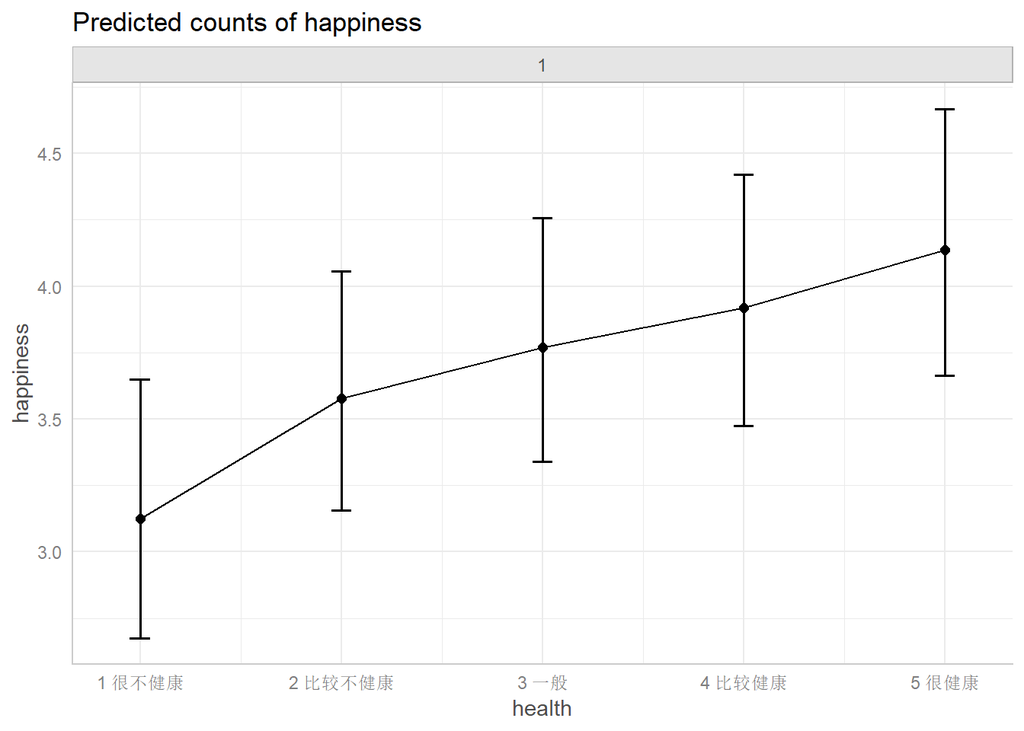

```r
#用图形直观查看健康对幸福感的影响
dat1 <-ggpredict(model2,terms=list("health"))
plot(dat1,facet=TRUE)+geom_line()
```

- 由图可看出，健康对幸福感有显著正面影响

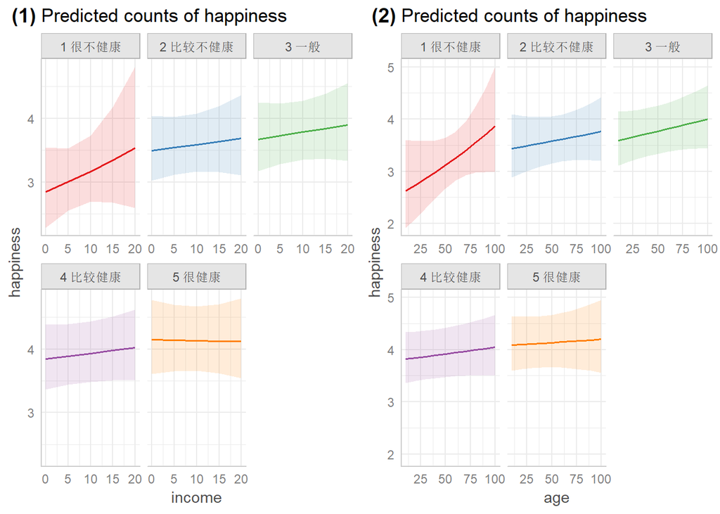

```r
#用图形直观查看收入和健康对幸福感的交互影响
dat2 <- ggpredict(model2,terms = list("income","health"))
P1 <- plot(dat2,facet=TRUE)+geom_line()
#用图形直观查看年龄和健康对幸福感的交互影响
dat3 <- ggpredict(model2,terms = list("age","health"))
P2 <- plot(dat3,facet=TRUE)+geom_line()
#将两张图并列放置
library(ggpubr)
ggarrange(P1,P2,ncol=2,labels=c("(1)","(2)"))
```

- 由图可以看出，在控制了其他变量的基础上，收入、年龄对幸福感的影响总体来说并不十分显著（只有当健康状况为很不健康时，幸福感变化较大）

**逐步回归**

```r
model3 <- step(model2)
```

```
## Start:  AIC=22361.96
## happiness ~ religion + marital + health + age + income + equity +
##     inc_ability + age * health + age * income + health * income
##
##                 Df Deviance   AIC
## - health:income  4   1050.9 22355
## - health:age     4   1052.0 22356
## - age:income     1   1050.3 22360
## - marital        6   1061.1 22361
## <none>               1049.9 22362
## - religion       1   1052.8 22363
## - inc_ability    3   1068.5 22375
## - equity         4   1111.0 22415
##
## Step:  AIC=22354.95
## happiness ~ religion + marital + health + age + income + equity +
##     inc_ability + health:age + age:income
##
##               Df Deviance   AIC
## - health:age   4   1053.0 22349
## - marital      6   1061.9 22354
## - age:income   1   1052.1 22354
## <none>             1050.9 22355
## - religion     1   1053.8 22356
## - inc_ability  3   1069.6 22368
## - equity       4   1112.1 22408
##
## Step:  AIC=22349.03
## happiness ~ religion + marital + health + age + income + equity +
##     inc_ability + age:income
##
##               Df Deviance   AIC
## - marital      6   1063.7 22348
## - age:income   1   1054.1 22348
## <none>             1053.0 22349
## - religion     1   1055.7 22350
## - inc_ability  3   1071.9 22362
## - equity       4   1114.6 22403
## - health       4   1117.3 22405
##
```

[output cut: 19 more lines]

```
## - age          1   1069.2 22349
## - inc_ability  3   1084.3 22360
## - equity       4   1126.3 22400
## - health       4   1130.7 22405
##
## Step:  AIC=22345.84
## happiness ~ religion + health + age + equity + inc_ability
##
##               Df Deviance   AIC
## <none>             1065.8 22346
## - religion     1   1068.0 22346
## - age          1   1070.2 22348
## - inc_ability  3   1085.8 22360
## - equity       4   1127.2 22399
## - health       4   1134.4 22406
```

```r
summary(model3)
```

```
##
## Call:
## glm(formula = happiness ~ religion + health + age + equity +
##     inc_ability, family = poisson(), data = glm_data)
##
## Deviance Residuals:
##      Min        1Q    Median        3Q       Max
## -1.92911  -0.14940   0.03002   0.20730   1.33521
##
## Coefficients:
##                            Estimate Std. Error z value Pr(>|z|)
## (Intercept)               1.1473466  0.0731297  15.689  < 2e-16 ***
## religion1 有宗教         -0.0307667  0.0203890  -1.509  0.13130
## health2 比较不健康        0.1141481  0.0439744   2.596  0.00944 **
## health3 一般              0.1708858  0.0428259   3.990 6.60e-05 ***
## health4 比较健康          0.2076741  0.0421698   4.925 8.45e-07 ***
## health5 很健康            0.2640749  0.0433915   6.086 1.16e-09 ***
## age                       0.0008853  0.0004208   2.104  0.03540 *
## equity2 比较不公平        0.0171432  0.0317366   0.540  0.58908
## equity3 说不上公平不公平  0.0619881  0.0317087   1.955  0.05059 .
## equity4 比较公平          0.1203323  0.0303511   3.965 7.35e-05 ***
## equity5 完全公平          0.2066683  0.0434474   4.757 1.97e-06 ***
## inc_ability2 合理        -0.0716521  0.0461973  -1.551  0.12090
## inc_ability3 非常合理    -0.1162733  0.0472984  -2.458  0.01396 *
## inc_ability4 非常不合理  -0.1913375  0.0601733  -3.180  0.00147 **
## ---
## Signif. codes:  0 '***' 0.001 '**' 0.01 '*' 0.05 '.' 0.1 ' ' 1
##
## (Dispersion parameter for poisson family taken to be 1)
##
##     Null deviance: 1260.9  on 6622  degrees of freedom
## Residual deviance: 1065.8  on 6609  degrees of freedom
## AIC: 22346
##
## Number of Fisher Scoring iterations: 4
```

- 逐步回归由系统自动挑选最佳的回归方程，我们可以看到系统自动去掉了不显著的交互项，级该交互效应在我们所研究的问题上没有统计学上的意义。最终得到的公式为 formula = happiness ~ religion + health + age + equity + inc_ability

## **有序因变量回归**

### **模型构建和分析**

**对于有次序的分类变量或者离散变量可以采用有序因变量回归。 该模型可以提供高低不同层次之间的两两比较和累积概率**  
**一般而言，回归系数β>0表明随解释变量正向变化，选择将、较高等级的可能性增加，选择较低等级的可能性下降；若回归系数β<0,反之。**

```r
library(ordinal)
#去除异常值-8
fmdata <- data%>%
  filter(health != -8,edu != -8,equity != -8,view != -8,inc_ability != -8)
#对收入进行对数变换，减少多重共线性，并在一定程度上消除量纲的影响
fmdata$income1 <- log(fmdata$income + 1)
#未回答的收入值-8进行对数变换后会产生NaN值，会影响回归分析，此处我们去掉含NaN记录
fmdata <- na.omit(fmdata)
```

```r
#构建一个新的变量happy存储happiness含义
fmdata$happy <- NA
fmdata$happiness <- as.character(fmdata$happiness)
fmdata$happy[as.numeric(fmdata$happiness)==1] <- "1 非常不幸福"
fmdata$happy[as.numeric(fmdata$happiness)==2] <- "2 比较不幸福"
fmdata$happy[as.numeric(fmdata$happiness)==3] <- "3 说不上幸福不幸福"
fmdata$happy[as.numeric(fmdata$happiness)==4] <- "4 比较幸福"
fmdata$happy[as.numeric(fmdata$happiness)==5] <- "5 非常幸福"
fmdata$happiness <- as.factor(fmdata$happiness)
fmdata$happy <- as.factor(fmdata$happy)

fmdata$inc_ability <- as.character(fmdata$inc_ability)
fmdata$inc_ability[as.numeric(fmdata$inc_ability)==1] <- "1 非常合理"
fmdata$inc_ability[as.numeric(fmdata$inc_ability)==2] <- "2 合理"
fmdata$inc_ability[as.numeric(fmdata$inc_ability)==3] <- "3 不合理"
fmdata$inc_ability[as.numeric(fmdata$inc_ability)==4] <- "4 非常不合理"
fmdata$inc_ability <- as.factor(fmdata$inc_ability)
```

```r
#给变量重新赋值，使结果显示更明显

fmdata$survey_type <- as.character(fmdata$survey_type)
fmdata$survey_type[as.numeric(fmdata$survey_type)==1] <- "1 城市"
fmdata$survey_type[as.numeric(fmdata$survey_type)==2] <- "2 农村"
fmdata$survey_type <- as.factor(fmdata$survey_type)

fmdata$gender <- as.character(fmdata$gender)
fmdata$gender[as.numeric(fmdata$gender)==1] <- "1 男"
fmdata$gender[as.numeric(fmdata$gender)==2] <- "2 女"
fmdata$gender <- as.factor(fmdata$gender)

fmdata$health <- as.character(fmdata$health)
fmdata$health[as.numeric(fmdata$health)==1] <- "1 很不健康"
fmdata$health[as.numeric(fmdata$health)==2] <- "2 比较不健康"
fmdata$health[as.numeric(fmdata$health)==3] <- "3 一般"
fmdata$health[as.numeric(fmdata$health)==4] <- "4 比较健康"
fmdata$health[as.numeric(fmdata$health)==5] <- "5 很健康"
fmdata$health <- as.factor(fmdata$health)

fmdata$equity <- as.character(fmdata$equity)
fmdata$equity[as.numeric(fmdata$equity)==1] <- "1 完全不公平"
fmdata$equity[as.numeric(fmdata$equity)==2] <- "2 比较不公平"
fmdata$equity[as.numeric(fmdata$equity)==3] <- "3 说不上公平不公平"
fmdata$equity[as.numeric(fmdata$equity)==4] <- "4 比较公平"
fmdata$equity[as.numeric(fmdata$equity)==5] <- "5 完全公平"
fmdata$equity <- as.factor(fmdata$equity)

fmdata$view <- as.character(fmdata$view)
fmdata$view[as.numeric(fmdata$view)==1] <- "1 非常少"
fmdata$view[as.numeric(fmdata$view)==2] <- "2 比较少"
fmdata$view[as.numeric(fmdata$view)==3] <- "3 一般"
fmdata$view[as.numeric(fmdata$view)==4] <- "4 比较多"
fmdata$view[as.numeric(fmdata$view)==5] <- "5 非常多"
fmdata$view <- as.factor(fmdata$view)
```

```r
#选取调查类型(surv_type)、性别(gender)、教育(edu1)、健康(health）、收入(income1)、社会公平(equity)、社会观点一致性(view)、收入合理性(inc_ability)8个自变量进行回归,选用cumalative link model模型进行拟合
fm1 <- clm(happy ~ survey_type + gender + edu1 + income1 + health + equity + view + inc_ability,data=fmdata)

summary(fm1)
```

```
## formula:
## happy ~ survey_type + gender + edu1 + income1 + health + equity + view + inc_ability
## data:    fmdata
##
##  link  threshold nobs logLik   AIC      niter max.grad cond.H
##  logit flexible  6583 -6632.02 13318.03 6(0)  2.41e-07 2.2e+05
##
## Coefficients:
##                           Estimate Std. Error z value Pr(>|z|)
## survey_type2 农村        -0.102620   0.057467  -1.786  0.07414 .
## gender2 女                0.251976   0.051737   4.870 1.11e-06 ***
## edu12 初中                0.066218   0.065116   1.017  0.30920
## edu13 高中/职校           0.095458   0.078315   1.219  0.22289
## edu14 专科                0.310245   0.106346   2.917  0.00353 **
## edu15 本科                0.226871   0.105337   2.154  0.03126 *
## edu16 研究生及以上        0.380399   0.255495   1.489  0.13652
## income1                   0.015180   0.007954   1.908  0.05633 .
## health2 比较不健康        0.779335   0.166884   4.670 3.01e-06 ***
## health3 一般              1.138812   0.163951   6.946 3.76e-12 ***
## health4 比较健康          1.456219   0.161429   9.021  < 2e-16 ***
## health5 很健康            2.084325   0.167384  12.452  < 2e-16 ***
## equity2 比较不公平       -0.083477   0.129397  -0.645  0.51885
## equity3 说不上公平不公平  0.266540   0.130422   2.044  0.04099 *
## equity4 比较公平          1.016496   0.126674   8.025 1.02e-15 ***
## equity5 完全公平          2.735668   0.194185  14.088  < 2e-16 ***
## view2 比较少              0.542300   0.438371   1.237  0.21606
## view3 一般                0.456946   0.426273   1.072  0.28374
## view4 比较多              0.777561   0.425790   1.826  0.06783 .
## view5 非常多              1.080751   0.433827   2.491  0.01273 *
## inc_ability2 合理        -1.425578   0.209422  -6.807 9.95e-12 ***
## inc_ability3 不合理      -1.885117   0.213239  -8.840  < 2e-16 ***
## inc_ability4 非常不合理  -2.321657   0.258723  -8.974  < 2e-16 ***
## ---
## Signif. codes:  0 '***' 0.001 '**' 0.01 '*' 0.05 '.' 0.1 ' ' 1
##
## Threshold coefficients:
##                                 Estimate Std. Error z value
## 1 非常不幸福|2 比较不幸福       -3.35778    0.50094  -6.703
## 2 比较不幸福|3 说不上幸福不幸福 -1.48675    0.49382  -3.011
## 3 说不上幸福不幸福|4 比较幸福   -0.08643    0.49379  -0.175
## 4 比较幸福|5 非常幸福            3.23783    0.49484   6.543
```

- 由拟合结果分析可知，性别、身体状况、社会公平性、收入合理性等因素对幸福感有显著影响
- 对比男性，女性更倾向于选择较高的幸福感选项
- 对比参照组（很不健康），个体越健康，处于较高幸福感的可能性就越大
- 对比参照组（认为社会非常不公平），个体越认为社会公平，处于较高幸福感的可能性越大
- 对比参照组（认为收入非常合理），个体认为收入越不合理，处于较高幸福感的可能性越小

```r
#逐步回归
fm2 <- step(fm1)
```

```
## Start:  AIC=13318.03
## happy ~ survey_type + gender + edu1 + income1 + health + equity +
##     view + inc_ability
##
##               Df   AIC
## <none>           13318
## - survey_type  1 13319
## - edu1         5 13320
## - income1      1 13320
## - gender       1 13340
## - view         4 13368
## - inc_ability  3 13454
## - health       4 13622
## - equity       4 13826
```

```r
summary(fm2)
```

```
## formula:
## happy ~ survey_type + gender + edu1 + income1 + health + equity + view + inc_ability
## data:    fmdata
##
##  link  threshold nobs logLik   AIC      niter max.grad cond.H
##  logit flexible  6583 -6632.02 13318.03 6(0)  2.41e-07 2.2e+05
##
## Coefficients:
##                           Estimate Std. Error z value Pr(>|z|)
## survey_type2 农村        -0.102620   0.057467  -1.786  0.07414 .
## gender2 女                0.251976   0.051737   4.870 1.11e-06 ***
## edu12 初中                0.066218   0.065116   1.017  0.30920
## edu13 高中/职校           0.095458   0.078315   1.219  0.22289
## edu14 专科                0.310245   0.106346   2.917  0.00353 **
## edu15 本科                0.226871   0.105337   2.154  0.03126 *
## edu16 研究生及以上        0.380399   0.255495   1.489  0.13652
## income1                   0.015180   0.007954   1.908  0.05633 .
## health2 比较不健康        0.779335   0.166884   4.670 3.01e-06 ***
## health3 一般              1.138812   0.163951   6.946 3.76e-12 ***
## health4 比较健康          1.456219   0.161429   9.021  < 2e-16 ***
## health5 很健康            2.084325   0.167384  12.452  < 2e-16 ***
## equity2 比较不公平       -0.083477   0.129397  -0.645  0.51885
## equity3 说不上公平不公平  0.266540   0.130422   2.044  0.04099 *
## equity4 比较公平          1.016496   0.126674   8.025 1.02e-15 ***
## equity5 完全公平          2.735668   0.194185  14.088  < 2e-16 ***
## view2 比较少              0.542300   0.438371   1.237  0.21606
## view3 一般                0.456946   0.426273   1.072  0.28374
## view4 比较多              0.777561   0.425790   1.826  0.06783 .
## view5 非常多              1.080751   0.433827   2.491  0.01273 *
## inc_ability2 合理        -1.425578   0.209422  -6.807 9.95e-12 ***
## inc_ability3 不合理      -1.885117   0.213239  -8.840  < 2e-16 ***
## inc_ability4 非常不合理  -2.321657   0.258723  -8.974  < 2e-16 ***
## ---
## Signif. codes:  0 '***' 0.001 '**' 0.01 '*' 0.05 '.' 0.1 ' ' 1
##
## Threshold coefficients:
##                                 Estimate Std. Error z value
## 1 非常不幸福|2 比较不幸福       -3.35778    0.50094  -6.703
## 2 比较不幸福|3 说不上幸福不幸福 -1.48675    0.49382  -3.011
## 3 说不上幸福不幸福|4 比较幸福   -0.08643    0.49379  -0.175
## 4 比较幸福|5 非常幸福            3.23783    0.49484   6.543
```

- 由逐步回归结果可得happiness ~ survey_type + gender + edu1 + income1 + health + equity + view + inc_ability。

### **模型结果可视化**

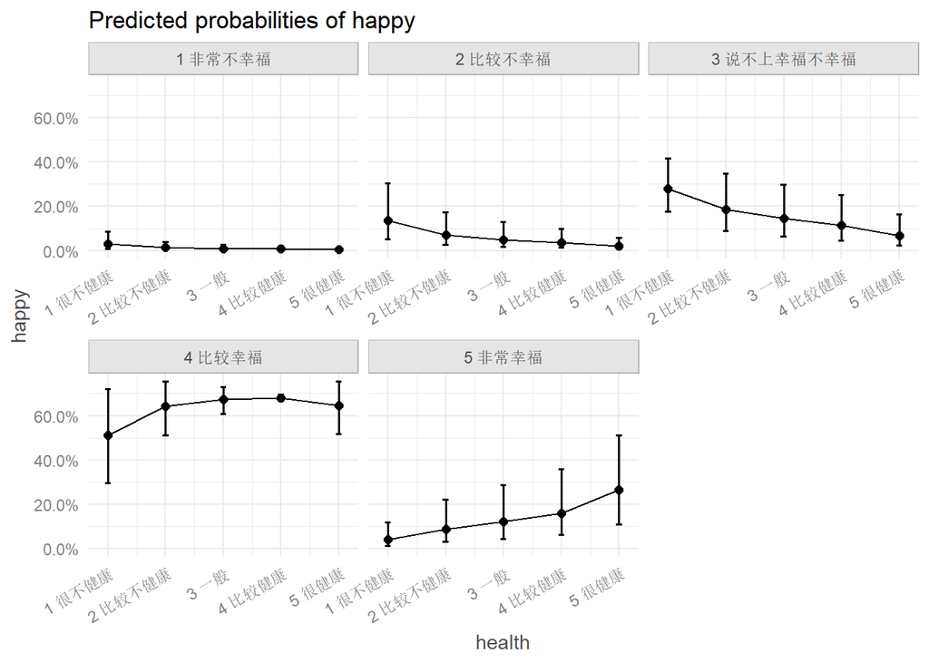

```r
library(ggeffects)

dat1 <- ggpredict(fm2,terms = list("health"))
plot(dat1,facet = TRUE)+
  geom_line()+
  theme(axis.text.x = element_text(angle = 30,hjust = 1))
```

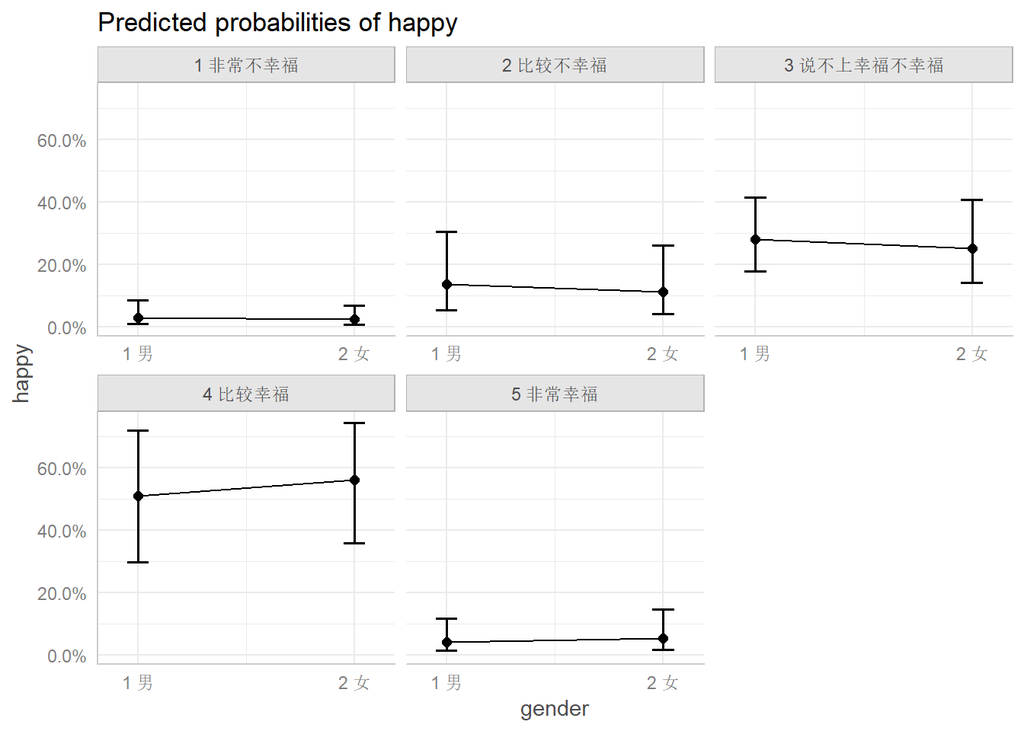

```r
dat2 <- ggpredict(fm2,terms = list("gender"))
plot(dat2,facet = TRUE)+
  geom_line()
```

- 各层次幸福感中，性别体现的差距不大。

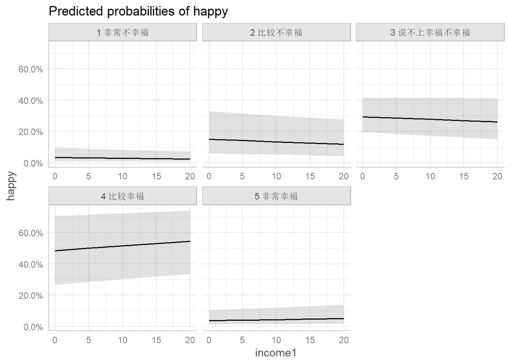

```r
dat3 <- ggpredict(fm2,terms = list("income1"))
plot(dat3,facet = TRUE)+
  geom_line()
```

- 由图分析，工资水平越高，其选择的高等级幸福感的概率会越大。

## **决策树**

```r
library(ROSE)
#在决策树中，我们采用和泊松回归同样的变量，将泊松回归整理过的数据集读入
tree_data <- glm_data
```

```r
#将幸福感重新转换为因子型
tree_data$happiness <- factor(tree_data$happiness)
```

```r
#由于模型需要，将幸福感分为“happy”和“unhappy”分成两类
tree_data$happiness <- as.character(tree_data$happiness)
tree_data$happiness[tree_data$happiness==1|tree_data$happiness==2|tree_data$happiness==3] <- "unhappy"
tree_data$happiness[tree_data$happiness==4|tree_data$happiness==5] <- "happy"
tree_data$happiness <- factor(tree_data$happiness)
summary(tree_data$happiness)
```

```
##   happy unhappy
##    5201    1422
```

- 我们看到，幸福与不幸福的数据量差距较大，数据可能存在不平衡

**平衡数据**

```r
#平衡数据
rose_train <- ROSE(happiness~religion+marital+health+age+income+equity+inc_ability,data=tree_data)
#将平衡后数据的类型从ROSE型变成数据框
rose_train <- data.frame(rose_train$data)
summary(rose_train$happiness)
```

```
##   happy unhappy
##    3226    3397
```

- 可以看出平衡过后的数据基本达到平衡

**生成决策树**

```r
library(caret)
library(rpart)
library(rattle)
#利用原始不平衡的数据生成决策树
rpart1 <- train(happiness~religion+marital+health+age+income+equity+inc_ability,data=tree_data,"rpart")
#利用平衡后的数据生成决策树
rpart2 <- train(happiness~religion+marital+health+age+income+equity+inc_ability,data=rose_train,"rpart")
```

```r
#不平衡数据生成模型的混淆矩阵
confusionMatrix(rpart1)
```

```
## Bootstrapped (25 reps) Confusion Matrix
##
## (entries are percentual average cell counts across resamples)
##
##           Reference
## Prediction happy unhappy
##    happy    74.7    17.4
##    unhappy   3.8     4.0
##
##  Accuracy (average) : 0.7873
```

```r
#平衡数据生成模型的混淆矩阵
confusionMatrix(rpart2)
```

```
## Bootstrapped (25 reps) Confusion Matrix
##
## (entries are percentual average cell counts across resamples)
##
##           Reference
## Prediction happy unhappy
##    happy    32.1    16.8
##    unhappy  16.8    34.2
##
##  Accuracy (average) : 0.6635
```

**输入决策模型并可视化**

```r
library(rpart.plot)
print(rpart2$finalModel)
```

```
## n= 6623
##
## node), split, n, loss, yval, (yprob)
##       * denotes terminal node
##
## 1) root 6623 3226 unhappy (0.4870904 0.5129096)
##   2) equity4 比较公平>=0.5 2527  838 happy (0.6683815 0.3316185) *
##   3) equity4 比较公平< 0.5 4096 1537 unhappy (0.3752441 0.6247559)
##     6) health5 很健康>=0.5 709  301 happy (0.5754584 0.4245416) *
##     7) health5 很健康< 0.5 3387 1129 unhappy (0.3333333 0.6666667) *
```

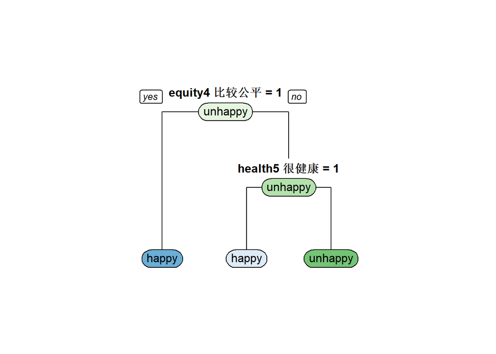

```r
rpart.plot(rpart2$finalModel,extra=0,tweak=1,type=1)
```

- 可以看出，这是一颗叶节点为3的决策树，这个简单的决策树预测模型的结论是，公平和健康是预测幸福感的重要因素